# Trump Tweet Text Analysis

## 2.3 Topic modeling - Themenanalyse

In dieser Ausarbeitung wird der zweite Schwerpunkt auf die Analyse der Themen gelegt, mit denen sich der Twitter account *@realDonaldTrump* befasst. Daher wird dieses Kapitel etwas ausführlicher ausgelegt. Somit soll die intensive Auseinandersetzung mit der verwendeten Methode sichergestellt werden.

Bisher wurde gezeigt, dass Wortzahlen und Visualisierungen etwas über Inhalte aussagen. Sentiment-Lexika wurden zum Feststellen der emotionalen Wertigkeit eines Dokuments verwendet. Nun soll über die Wortzahlen hinaus die zugrundeliegenden Themen in einer Sammlung von Dokumenten aufgedeckt werden. Dazu wird ein Wahrscheinlichkeitsmodell für *Dokumente* verwendet. **Latent Dirichlet allocation** (LDA) wurde von David Blei, Andrew Ng und Michael I. Jordan vorgestellt. Es darf nicht mit *Linear discriminant analysis*, ebenfalls abgekürzt mit LDA, verwechselt werden. In diesem Dokument bezieht sich LDA auf *Latent Dirichlet allocation*.

LDA ist ein Standard-Themen-Modell, durch das *topic modeling* implementiert werden kann. Es sucht nach Mustern von Wörtern, die innerhalb und über eine Sammlung von Dokumenten hinweg auftreten, auch bekannt als Korpus (Gesamtheit zusammengehöriger Textdaten). Dabei werden $k$ Themen innerhalb eines Korpus gefunden, indem für jedes Dokument eine separate Sammlung von Wörtern erstellt und Wörter ausgegeben werden, um nach Mustern zu suchen, in denen Wörter zusammengehörig vorkommen. Die Reihenfolge der Wörter ist dabei unerheblich.

Die ausgegebenen Themen sind eine Liste aller Wörter im Korpus, denen eine Auftrittswahrscheinlichkeit innerhalb der Themen zugeordnet wird. Worte, die häufig zusammen auftreten, bekommen höhere $p$-Values (genauer $\beta$-Werte) innerhalb eines oder mehrer Themen zugeordnet.

Da die Methode nach Mustern und Zusammenhängen sucht, statt sie vorherzusagen, kann sie den *Unsupervised Learning*-Algorithmen aus dem Bereich des Maschinellen Lernens zugeordnet werden. *Topic modeling* kann daher mit *Clustering* verwechselt werden. Sie lassen sich trotz ihrer Ähnlichkeit unterscheiden: Gängige Clustering-Techniken wie *k-means* und *hierarchical clustering* basieren auf dem Abstand zwischen Objekten, der ein kontinuierliches Maß ist. Darüber hinaus ist jedes zu gruppierende Objekt einem einzelnen Cluster zugeordnet. Themenmodelle wie LDA basieren auf Worthäufigkeiten, was hingegen ein diskretes Maß ist. Zudem ist jedes Objekt (hier ein Dokument innerhalb eines Korpus) ein Teilmitglied jedes Themas.

Die nachfolgende Grafik erweitert den Text-Mining-Prozess von zuvor um *Topic Modeling*

[figure not shown]

Das Trainieren des Modells kann mittels der `LDA()`-Funktion implementiert werden. Um es auszuführen muss zunächst eine *Document Term Matrix* (DTM) erstellt und an `LDA()` übergeben werden. Ein `matrix`-Object ist ähnlich aufgebaut zu einem `DataFrame`-Objekt. Jedoch werden die Bestandteile statt *Observation* und *Variable* mit *Zeilen* und *Spalten* bezeichnet, wobei jede Spalte aus einem Datentypen bestehen muss. Eine DTM hat eine Zeile für jedes Document (entspricht im Praxisbeispiel später Tweets) und eine Spalte für jedes einzigartige Word oder Begriff über alle Dokumente in einem Corpus hinweg. Die Werte innerhalb der DTM sind die Zählungen oder Zahl der Verwendung jedes Begriffes innerhalb des zugehörigen Dokuments. Das führt dazu, dass i.d.R. der Großteil aller Werte $0$ enspricht. In einem solchen Fall spricht man von einer *dünnbesetzten Matrix*. Eine DTM kann mithilfe der Funktion `cast_dtm()` erstellt werden. Als Eingabewert erhält sie das *tidy* DataFrame aus den vorherigen Schritten des Preprocessings, das die Wortzählungen enthält.

Das Trainieren des Modells kann mittels der `LDA()`-Funktion implementiert werden. Sie gibt `LDA`-Objekt zurück, welches die Information über die Auftrittswahrscheinlichkeiten enthält. Sie werden in $\beta$-Werte übersetzt, welche letztlich interpretiert werden können.

```r
library(topicmodels)

lda_fitted <- LDA(
  dtm_input,
  k = 2,
  method = "Gibbs",
  control = list(seed = 42)
)
```

Der code-Chunk zeigt die Verwendung von `LDA()`. Das erste Argument ist die DTM. Das zweite Argument `k` gibt an, wie viele Themen bestimmt werden sollen. `method` gibt die zu verwendene Schätzmethode an. Der *Default* Wert hier wäre eine schnelle Annäherung. Wenn jedoch vollständigere Methode aber dafür mit längerer Laufzeit bevorzugt wird, sollte der *Gibbs*-Sampler verwendet werden. Es kann zudem ein optionaler Seed gesetzt werden, um Repruduzierbarkeit zu unterstützen. Die Laufzeit der Methode kann bis zu einige Stunden betragen.

Das trainierte Modell ist ein spezielles R-Objekt, das für das Package `topicmodels` kodiert ist, wie es auch bei dem DTM der Fall ist. Funktionen wie `str()`, `summary()` oder `glimpse()` können den Inhalt des Modells anzeigen.

```r
glimpse(lda_fitted)
```

Die Evaluierung des Modell-Objekts kann mithilfe eines der Werkzeuge aus dem `tidytext` Package erledigt werden. Insbesondere sind die wichtigsten Ergebnisse eines Themenmodells die Themen selbst: das Wörterbuch aller Wörter im Korpus, sortiert nach der Wahrscheinlichkeit, mit der jedes Wort im Rahmen dieses Themas auftritt. In diesem Fall kann die `tidy()`-Funktion die Matrix mit Auftrittswahrscheinlichkeiten der Themen in eine Form umwandeln, die erneut den *Tidy-Data*-Prinzipien folgt und somit auf einfache Weise mit `ggplot2` zur Visualisierung verwendet werden kann. Die Auftrittswahrscheinlichkeiten $\beta$ sollten zudem absteigend sortiert werden:

```r
lda_fitted %>%
  tidy(matrix = "beta") %>%
  arrange(desc(beta))
```

Es resultiert die geordnete Auflistung der Wahrscheinlichkeiten. Es steht nun die Frage aus, wie man entscheiden soll, wie $k$ zu definieren ist. $k$ gibt die Anzahl der Themen an, nach denen `LDA` suchen soll. Die Antwort auf diese Frage steht im direkten Zusammenhang mit der Interpretation des Modells. Ein *Topic Model* zu interpretieren ist ein subjectiver Prozess. Denn wie auch bei anderen *Unsupervised Learning* Methoden, wie bspw. *Clustering*, gibt der Output der Modelle an, woraus die Cluster bestehen. Es fehlt jedoch eine Beschreibung der Richtung, ein Hinweis auf die Bedeutung der Ergebnisse. Die Bedeutung kann nicht trennscharf durch die Methoden bestimmt werden. Hier könnten bspw. Missverständnisse je nach unterschiedlicher Kultur der Betrachter auftreten. Gleichwohl könenn ganz andare, unerwartete Dimensionen als Stöfaktor in die Bewertung eingehen. Die Entscheidung also, wie viele Themen zu bestimmen sind, hängt vom Betrachter ab. Die **Schlüsselerkenntnis** hier sollte sein, dass $k$ so gewählt sind, dass die Ergebnisse ausreichend unterschiedlich zueinander sind, sodass der Betrachter sinnhafte Erkenntnisse extrahieren kann. Die Themen sollten sich nicht wiederholen.

Grundsätzlich kann man sich an folgendes Muster halten:

- weitere Themen hinzuzunehmen ($k$ erhöhen), ist so lange in Ordnung, wenn sie unterschiedlich zueinander sind
- wenn Themen sich wiederholen, wird $k$ zu groß
- Themen sollten durch einen *Überschrift* oder ein *Name* beschrieben werden, um sie greifbarer für die Interpretation zu machen

Die Implementation und das Ergebnis einer *Latent Dirichlet Allocation* wird im Praxisteil deutlich.

Referenz: https://www.tidytextmining.com/topicmodeling.html

# 3 Dokumentation der Durchführung der Textanalyse

## 3.1 Beschreibung der Daten

```r
glimpse(tweets)
```

```
Observations: 38,887
Variables: 7
$ source         <chr> "Twitter for iPhone", "Twitter for iPhone", "Twitter for iPhone", "Twitter for iPho...
$ text           <chr> "At the request of Democrats, I have delayed the Illegal Immigration Removal Proces...
$ created_at     <chr> "Sat Jun 22 18:56:35 +0000 2019", "Sat Jun 22 18:56:34 +0000 2019", "Sat Jun 22 18:...
$ retweet_count  <int> 5086, 3705, 4960, 8597, 7257, 7943, 4731, 5799, 9494, 6514, 4959, 9988, 2393, 26398...
$ favorite_count <int> 17463, 15487, 19558, 34033, 30890, 28729, 17960, 0, 0, 27306, 0, 51896, 11015, 1299...
$ is_retweet     <lgl> FALSE, FALSE, FALSE, FALSE, FALSE, FALSE, FALSE, TRUE, TRUE, FALSE, TRUE, FALSE, FA...
$ id_str         <chr> "1142506687020130306", "1142506683660455936", "1142506680300789761", "1142476293331...
```

## 3.2 Preprocessing & Tidying

Beim ersten Inspizieren der geladenen Daten fällt zunächst auf, dass die Angabe über das Tweet-Erstellungsdatum (`created_at`) als `character` formatiert ist:

```r
class(tweets$created_at)
```

```
[1] "character"
```

Diese Variable wird als Datumsangabe benötigt. Mit der Funktion `as.POSIXct` lassen sich Datumsangaben nach dem POSIX-Standard erzeugen, welche sich gut mit R verarbeiten lassen. Die Zeitangaben aus der Quelle lassen sich mittels `strptime` von `character` Repräsentationen in POSIX*-Objekte konvertieren. Zusätzlich muss für die Tweet Analyse bedacht werden, dass es sich bei den Zeitangaben i.d.R. nicht um die Zeitzone handelt, die wir in Mitteleuropa normalerweise verwenden (GMT, bzw. UTC). Wenn wir die Tweets des Accounts *@realDonaldTrump* untersuchen, ist es jedoch sinnvoll, die Zeitangaben in der Zeitzone des Besitzers zu beschreiben, um die Zeitverschiebung zu berücksichtigen.

```r
# prev <- Sys.getlocale("LC_TIME") # falls abweichend von "German_Germany.1252"
german <- "German_Germany.1252"
Sys.setlocale("LC_TIME", "C") # auf windows system muss zunächst die locale angepasst werden
```

```
[1] "C"
```

```r
POSIX_times_formatted <- strptime(tweets$created_at, "%a %b %d %H:%M:%S %z %Y")
# Trumpian time
tweets$created_at <- with_tz(as.POSIXct(POSIX_times_formatted), "EST")
Sys.setlocale("LC_TIME", german)
```

```
[1] "German_Germany.1252"
```

```r
summary(tweets)
```

```
    source              text             created_at                  retweet_count    favorite_count
 Length:38887       Length:38887       Min.   :2009-05-04 13:54:25   Min.   :     0   Min.   :     0
 Class :character   Class :character   1st Qu.:2013-07-23 19:19:14   1st Qu.:    21   1st Qu.:    22
 Mode  :character   Mode  :character   Median :2015-01-26 22:15:13   Median :   269   Median :   112
                                       Mean   :2015-04-28 02:00:19   Mean   :  5431   Mean   : 19062
                                       3rd Qu.:2016-09-15 07:41:19   3rd Qu.:  7036   3rd Qu.: 11740
                                       Max.   :2019-06-22 13:56:35   Max.   :369530   Max.   :633253
 is_retweet         id_str
 Mode :logical   Length:38887
 FALSE:37128     Class :character
 TRUE :1701      Mode  :character
 NA's :58
```

Ein großer Teil der Analysen zielen darauf ab, die Source des Tweets zu unterscheiden. Es wird häufig behauptet, dass Unterschiede im Posting-Verhalten zwischen Posts von einem iPhone und Android Device festgestellt werden können. Diese Analyse soll bestätigen, dass dem so ist. Man weiß, dass Donald Trump zumindest eine Zeit lang ein Android Device verwendete (https://www.theverge.com/2015/10/5/9453935/donald-trump-twitter-strategy). Dieser Zeitraum kann festgestellt werden:

```r
unique(tweets$source)
```

```
 [1] "Twitter for iPhone"       "Twitter Media Studio"     "Twitter Web Client"
 [4] "Twitter for iPad"         "Media Studio"             "Twitter Ads"
 [7] "Twitter for Android"      "Periscope"                "TweetDeck"
[10] "Instagram"                "Mobile Web (M5)"          "Twitter Mirror for iPad"
[13] "Twitter QandA"            "Facebook"                 "Twitter for BlackBerry"
[16] "Neatly For BlackBerry 10" "Twitter for Websites"     "Twitlonger"
[19] "Vine - Make a Scene"      "TwitLonger Beta"
```

```r
min(tweets[tweets$source == "Twitter for Android",]$created_at)
```

```
[1] "2013-02-05 20:53:40 EST"
```

```r
max(tweets[tweets$source == "Twitter for Android",]$created_at)
```

```
[1] "2017-03-25 09:41:14 EST"
```

Für den Twitter-Account *@realDonaldTrump* wurde im Zeitraum Februar 2013 bis März 2017 unter anderem ein Android Device verwendet. Das gesamte Dataset wird auf diesen Zeitraum eingeschränkt, um sicherszustellen, dass in die Analysen keine Tweets einfließen, zu dessen Zeitpunkt das Android Device nicht existierte. Datei wird von vollen Jahren ausgegangen, also 01.01.2014 bis 31.12.2016. Außerdem wird auf Android und iPhone Devices eingeschränkt. Zusätzlich wird das Dataset weiter “gesäubert”:

```r
names(tweets) <- c("device", "text", "created", "retweet_count", "favorite_count", "is_retweet", "id")
names(tweets)
```

```
[1] "device"         "text"           "created"        "retweet_count"  "favorite_count" "is_retweet"
[7] "id"
```

```r
tweets <- tweets %>%
  mutate(device = str_replace(device, "Twitter for ", "")) %>%
  filter(device %in% c("Android", "iPhone") &
           created >= "2014-01-01" &
           created <= "2016-12-31") %>%
  select(id, device, created, text)
tweets$device <- as.factor(tweets$device)
tweets[1:5,]
```

| id | device | created | text |
| --- | --- | --- | --- |
| 814958820980039681 | Android | 2016-12-30 17:18:18 | Russians are playing @CNN and @NBCNews for such fools - funny to watch, they don't have a clue! @FoxNews totally gets it! |
| 814920722208296960 | iPhone | 2016-12-30 14:46:55 | Join @AmerIcan32, founded by Hall of Fame legend @JimBrownNFL32 on 1/19/2017 in Washington, D.C.… https://t.co/9WJZ8iTCQV |
| 814919370711461890 | Android | 2016-12-30 14:41:33 | Great move on delay (by V. Putin) - I always knew he was very smart! |
| 814484710025994241 | iPhone | 2016-12-29 09:54:21 | My Administration will follow two simple rules: https://t.co/ZWk0j4H8Qy |
| 814231064847728640 | iPhone | 2016-12-28 17:06:28 | 'Economists say Trump delivered hope' https://t.co/SjGBgglIuQ |

## 3.3 Exploration

Eine Betrachtung der *Absolut*-Zahlen / Zählungen der Posts je Device:

```r
tweets %>%
  count(device) %>%
  mutate(percent = n/sum(n))
```

| device | n | percent |
| --- | --- | --- |
| Android | 10555 | 0.8167608 |
| iPhone | 2368 | 0.1832392 |

Das Android Device wird wesentlich reger verwendet. Ein Hinweis darauf, dass wir in den folgenden Analysen, wo sinnvoll, relative Werte verwenden sollten, um somit dem Klassifizierungs-Überhang (engl. Prevalence) der Klasse *‘Android’* entgegenzuwirken.

### 3.3.1 Tweet-Uhrzeit

Wann Postet der Twitter Account *@realDonaldTrump* ? Die Zeiten wurden hierfür bereits in die richtige Form gebracht (s.o.), denn hier ist vor allem die Zeitzone zu beachten.

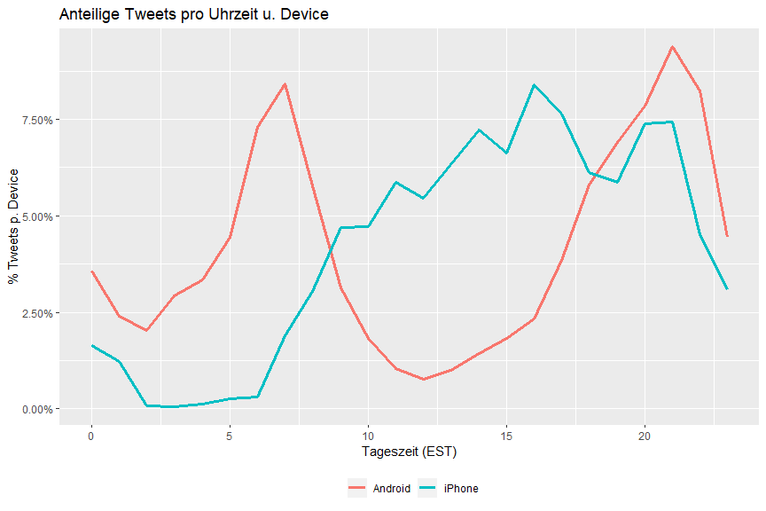

```r
tweets %>%
  mutate(hour = hour(created)) %>%
  count(device, hour) %>%
  group_by(device) %>%
  mutate(percent = n / sum(n)) %>%
  ungroup() %>%
  ggplot(aes(hour, percent, color = device)) +
  geom_line(size = 1.1) +
  scale_y_continuous(labels = percent_format()) +
  theme(legend.position = 'bottom') +
  labs(title = "Anteilige Tweets pro Uhrzeit u. Device",
       x = "Tageszeit (EST)",
       y = "% Tweets p. Device",
       color = "")
```

Darstellung als Boxplots:

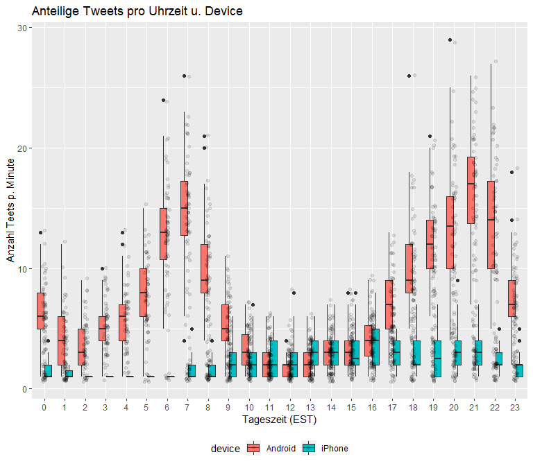

```r
tweets %>%
  mutate(minute = minute(created),
         hour = hour(created)) %>%
  count(hour, minute, device) %>%
  ggplot(aes(as.factor(hour), n, fill = device)) +
  geom_boxplot() +
  geom_jitter(width = 0.1, alpha = 0.1) +
  theme(legend.position = 'bottom') +
  labs(title = "Anteilige Tweets pro Uhrzeit u. Device",
       x = "Tageszeit (EST)",
       y = "Anzahl Teets p. Minute",
       color = "")
```

### 3.3.2 Retweets

Über den Account *@realDonaldTrump* werden Tweets anderer User retweetet. Ein Tweet wird als Retweet eingeordnet, wenn er mit doppelten Anführungszeichen (*“*) beginnt. Andere Twitter User machten die Beobachtung, dass* @realDonaldTrump* diese besondere Angewohnheit für das Retweeten hat (statt die dafür eigentlich vorgesehene Funktion oder den gängigen Kürzel ‘*RT*’ zu verwenden). Die folgende Grafik zeigt, auf welche Devices sich diese Retweets verteilen:

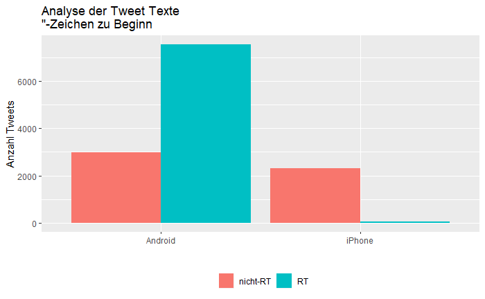

```r
tweets %>%
  count(device, quoted = ifelse(str_detect(text, '^"'), "RT", "nicht-RT")) %>%
  ggplot(aes(device, n, fill = quoted)) +
  geom_bar(stat = "identity", position = "dodge") +
  theme(legend.position = 'bottom') +
  labs(title = 'Analyse der Tweet Texte\n"-Zeichen zu Beginn',
       x = "",
       y = "Anzahl Tweets",
       fill = "")
```

### 3.3.3 Tippfehler

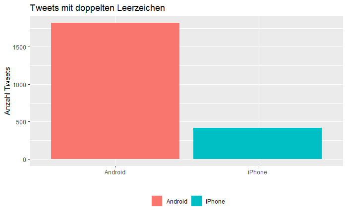

```r
tweets %>%
  filter(str_detect(text, pattern = "\\s\\s")) %>%
  count(device) %>%
  ggplot(aes(device, n, fill = device)) +
  geom_col() +
  theme(legend.position = 'bottom') +
  labs(title = "Tweets mit doppelten Leerzeichen",
       x = "",
       y = "Anzahl Tweets",
       fill = "")
```

### 3.3.4 Links, Bilder, Ankündigungen

Ein weiterer Unterschied, der anhand der Daten belegt werden kann ist folgender: Vom Android Device wird selten bis nie ein Link oder ein Bild gepostet. Der Präsident scheint dazu zu tendieren, Tweets wie die folgenden zu schreiben:

```r
tweets %>% filter(str_detect(text, "Very dishonest!")) %>% .$text
```

```
[1] "The failing @nytimes has become a newspaper of fiction. Their stories about me always quote non-existent unnamed sources. Very dishonest!"
[2] "The media is going crazy. They totally distort so many things on purpose. Crimea, nuclear, \"the baby\" and so much more. Very dishonest!"
[3] "I am always on the front page of the failing @nytimes, but when I won the GOP nomination, I'm in the back of the paper. Very dishonest!"
```

Während *The Ghost* via iPhone bisweilen Ankündigungen, Danksagungen oder sonstige Grüße ausspricht:

```r
tweets %>% filter(str_detect(text, "Thank you W")) %>% .$text
```

```
 [1] "Thank you Wisconsin! My Administration will be focused on three very important words: jobs, jobs, jobs! Watch:… https://t.co/iEGWZLuiFE"
 [2] "Thank you Wilmington, North Carolina. We are 3 days away from the CHANGE you've been waiting for your entire life!… https://t.co/6ZJZRBfLST"
 [3] "Thank you Waukesha, Wisconsin! \nFull transcript of my speech, #FollowTheMoney:\nhttps://t.co/Xb1yyDSNNf https://t.co/WdKK6nJCZW"
 [4] "Thank you Windham, New Hampshire! #TrumpPence16 #MAGA https://t.co/ZL4Q01Q49s"
 [5] "Thank you Washington! Honored to say, on behalf of our great movement, we have broken the all time record for votes in GOP primary history."
 [6] "Thank you Washington! #Trump2016\n#MakeAmericaGreatAgain https://t.co/v9glTwj6gy"
 [7] "Thank you West Virginia!\n#MakeAmericaGreatAgain #Trump2016 https://t.co/iCGcF21fWY"
 [8] "Thank you West Virginia. Let's keep it going. Go out and vote on Tuesday - we will win big. #Trump2016"
 [9] "Thank you Wilkes-Barre, Pennsylvania! \n#MakeAmericaGreatAgain #Trump2016 \nhttps://t.co/FJbNlidwJF"
[10] "Thank you West Chester, Pennsylvania!\n#PAPrimary #VoteTrump\nhttps://t.co/Qva1QtmhpS https://t.co/CF9SYBqka7"
[11] "Thank you Warwick, Rhode Island!\n#RIPrimary #VoteTrump \nhttps://t.co/V0d4CuS1xf https://t.co/GU3p28VMe0"
[12] "Thank you Waterbury, Connecticut!\n#MakeAmericaGreatAgain #Trump2016\nhttps://t.co/5eZ5nVQbE9 https://t.co/OoQAAKWUUq"
[13] "Thank you Willie Robertson! \n#VoteTrump #MakeAmericaGreatAgain  https://t.co/0TUpaNfUmR"
[14] "Thank you Worcester, Massachusetts!#MakeAmericaGreatAgain #Trump2016 https://t.co/D6QinyBLW6 https://t.co/sZDJr3Tkd8"
```

Diese Tweets sind zudem in einem ähnlichen Muster geschrieben, fast so, als diene eine interne Vorgabe als Vorlage. Insgesamt wirkt es “professionell”. So würde man es von einem Kampagnen-Helfer oder -Mitarbeiter erwarten.

Zudem ist der Anteil an Hashtags (#) wesentlich höher als in den Tweets des Präsidenten, was weiter unten noch untermauert wird. Hier zunächst die Darstellung der Zählungen der Tweets mit und ohne Links/Bildern:

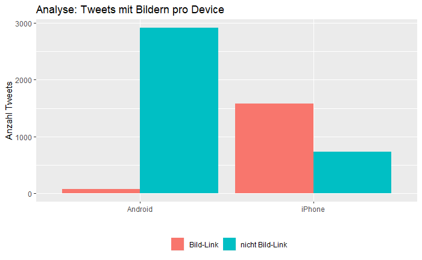

```r
#  Anzahl der Tweets mit und ohne Bild-Link pro Device bestimmen
tweets_pictures <- tweets %>%
  filter(!str_detect(text, '^"')) %>%
  mutate(picture = ifelse(
    str_detect(text, "t.co"),
    "Bild-Link",
    "nicht Bild-Link")) %>%
  count(device, picture)
# bar plot
ggplot(tweets_pictures, aes(device, n, fill = picture)) +
  geom_col(position = position_dodge()) +
  theme(legend.position = 'bottom') +
  labs(title = "Analyse: Tweets mit Bildern pro Device",
       x = "",
       y = "Anzahl Tweets",
       fill = "")
```

### 3.3.5 Dig Deeper: Inhalte und Worte

Der Unterschied zwischen den beiden Devices ist hinreichend nachgestellt worden. Nun wird der Inhalt der Tweets betrachtet, um somit einer Aussage näher zu kommen, ob der Präsident einen oder mehrere *Ghosts* für seinen Twitter Account beschäftigt, so lautet schließlich die Hypothese.

Für diese Analyse werden die Tweets im strengen *Tidy*-Format benötigt. Dazu wird wie zuvor beschrieben die Funktion `unnest_token` verwendet. Es erfolgen weitere Schritte:

- Die Bild-Links werden mit `str_replace_all` entfernt (das regex lautet `"https://t.co/[A-Za-z\\d]+|&amp;"`).
- Es werden außerdem mittels des DataFrames `stop_words` aus dem `tidytext` Package Wörter ohne relevante Aussagekraft aus dem Analyse-Dataset entfernt.
- Für `unnest_tokens` wird ein benutzerdefiniertes Muster verwendet: `([^A-Za-z\\d#@']|'(?![A-Za-z\\d#@]))`, welches in der Lage ist Erwähnungen anderer Nutzer (@…) und Hashtag-Nennungen (#…) zu erhalten. Die *default*-Werte der Funktion würden Sonderzeichen wie diese entfernen.
- Vorrangig Ziffern werden mit `str_detect(word, "[a-z]")` herausgefiltert.

```r
tweets_tidy <- tweets %>%
  filter(!str_detect(text, '^"')) %>%
  mutate(text = str_replace_all(text, "https://t.co/[A-Za-z\\d]+|&amp;", "")) %>%
  unnest_tokens(word, text, token = "regex", pattern = "([^A-Za-z\\d#@']|'(?![A-Za-z\\d#@]))") %>%
  filter(!word %in% stop_words$word,
         str_detect(word, "[a-z]"))
tweets_tidy[1:5,]
```

| id | device | created | word |
| --- | --- | --- | --- |
| 418365112844824577 | Android | 2014-01-01 07:56:30 | day |
| 418365112844824577 | Android | 2014-01-01 07:56:30 | rest |
| 418365112844824577 | Android | 2014-01-01 07:56:30 | life |
| 418542137899491328 | Android | 2014-01-01 19:39:56 | expensive |
| 418542137899491328 | Android | 2014-01-01 19:39:56 | global |

Nun können die häufigsten Wörter ausgegeben werden:

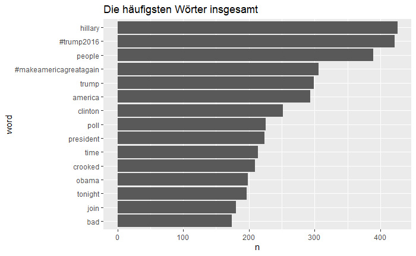

```r
tweets_tidy %>%
  count(word, sort = T) %>%
  top_n(15, n) %>%
  mutate(word = reorder(word, n)) %>%
  ggplot(aes(word, n)) +
  geom_col() +
  coord_flip() +
  ggtitle("Die häufigsten Wörter insgesamt")
```

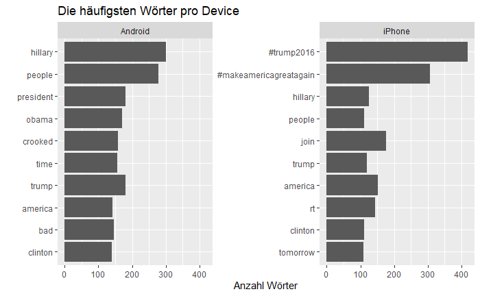

```r
tweets_tidy %>%
  count(device, word, sort = T) %>%
  group_by(device) %>%
  top_n(10, n) %>%
  ungroup() %>%
  mutate(word = reorder(word, n)) %>%
  ggplot(aes(word, n)) +
  geom_col() +
  coord_flip() +
  facet_wrap(~ device, scales = "free_y") +
  labs(title = "Die häufigsten Wörter pro Device",
       x = "",
       y = "Anzahl Wörter")
```

### 3.3.6 n-grams

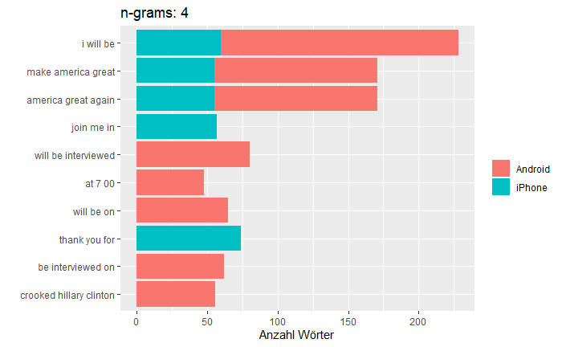

```r
tweets %>%
  filter(!str_detect(text, '^"')) %>%
  mutate(text = str_replace_all(text, "https://t.co/[A-Za-z\\d]+|&amp;", "")) %>%
  unnest_tokens(word, text, token = "ngrams", n = 3) %>%
  count(device, word, sort = T) %>%
  drop_na() %>%
  mutate(word = reorder(word,n)) %>%
  top_n(13, n) %>%
  ggplot(aes(word, n, fill = device)) +
  geom_col() +
  coord_flip() +
  labs(title = "n-grams: 4",
       y = "Anzahl Wörter",
       x="", fill = "")
```

### 3.3.7 Nachweis: Unterschiedliche Tweet-Autoren

Möchte man nun die Verwendung von Worten je Device betrachten, kann man sich das *Quotenverhältnis* zur Hilfe nehmen. Dies ist die bessere Variante als ein schlichter Vergleich der Zählungen, weil wie zuvor beschrieben somit der Überhang der Klassifizierung *‘Android’* beachtet wird. David Robinson aus der Data Science Community dient als Referenz für die nachfolgende Statistik. Das Log-Quotenverhältnis (auch *Odd-Ratio*) berechnet sich wie folgt:

$$\log_2
\left(
\frac
{\frac{\text{# von Android}+1}{\text{Gesamt # Wörter Android}+1}}
{\frac{\text{# von iPhone}+1}{\text{Gesamt # Wörter iPhone}+1}}
\right)$$

Die Wörter werden für die Analyse auf ein Vorkommen von mindestens fünf Mal auf beiden Devices eingeschränkt. In einigen Fällen bedeutet das, dass weniger Vorkommen von dem Android Device als vom iPhone gezählt werden, jedoch nie weniger als fünf insgesamt. Wenn ein Wort auf dem Android einmalig auftritt, dann fallen die restlichen vier dem iPhone Device zu.

```r
tweets_ratios <- tweets_tidy %>%
  count(word, device) %>%
  group_by(word)  %>%
  filter(sum(n) >= 5) %>%
  spread(device, n, fill = 0) %>%
  ungroup() %>%
  mutate_if(is.numeric, list(~ (. + 1) / sum(. + 1))) %>%
  mutate(oddratio = log2(Android / iPhone)) %>%
  arrange(desc(oddratio))
tweets_ratios[1:5,]
```

| word | Android | iPhone | oddratio |
| --- | --- | --- | --- |
| ebola | 0.002540650 | 7.260582e-05 | 5.128969 |
| stupid | 0.001755358 | 7.260582e-05 | 4.595537 |
| africa | 0.001662971 | 7.260582e-05 | 4.517534 |
| warming | 0.001616778 | 7.260582e-05 | 4.476892 |
| hell | 0.001478197 | 7.260582e-05 | 4.347609 |

Im Anschluss können die meist verwendeten Wörter, geordnet nach den *Odd-Ratios*, geplottet werden. Eine explizite Unterscheidung der Device-Klassen ist nun nicht mehr möglich, weil die Raten über die Klassen hinweg erstellt wurden. Jedoch wurde die Berechnung so ausgelegt, dass die Quotenverhältnisse aus Sicht der Klasse *‘Android’* definiert sind. Somit können Werte größer als Null dem Android Device und Werte kleiner Null iPhone zugeordnet werden:

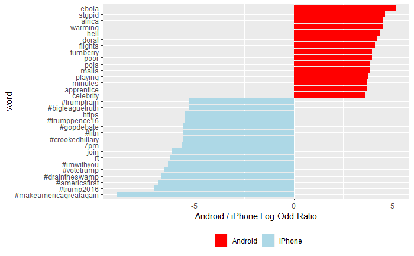

```r
tweets_ratios %>%
  group_by(oddratio > 0) %>%
  top_n(15, abs(oddratio)) %>%
  ungroup() %>%
  mutate(word = reorder(word, oddratio)) %>%
  ggplot(aes(word, oddratio, fill = oddratio < 0)) +
  geom_bar(stat = "identity") +
  coord_flip() +
  ylab("Android / iPhone Log-Odd-Ratio") +
  theme(legend.position = 'bottom') +
  scale_fill_manual(name = "", labels = c("Android", "iPhone"),
                    values = c("red", "lightblue"))
```

Bis hierhin lassen sich die ersten Erkenntnisse der Explorativen Analyse zusammenfassen:

- Es ist tatsächlich so, dass die meisten Hashtag-Markierungen vom iPhone stammen. Wenn der Präsident Hashtags verwendet, sind das allenfalls Hashtags aus Retweets.
- Das iPhone ist für offizielle Ankündigungen im Stil von Einladungen verantwortlich. Das Erkennt man an Wortfragmenten wie *“7pm”* oder *“join”* (*“Join me in Houston, Texas tomorrow night at 7 pm!”*)
- Emotionalere Tweets stammen vom Präsidenten selbst. Worte wie “poorly” oder “stupid” sind nicht nur Worte, die untypisch für eine Campagne oder eine offizielle Stelle sind, sie sind auch eindeutig dem Android und demnach dem Präsidenten zuzuordnen, wenn man die Hypthese zu unterstützen versucht.

## 3.4 Sentiment-Analyse

Für den erstem Teil der Sentimentanalyse werden die Ergebnisse aus der vorherigen Analyse mit dem “NRC” Sentiment-Lexikon verknüpft. Dieses Sentiment-Lexikon wird hier mit `get_sentiment_dictionary` aus dem `syuzhet` Package geladen, weil es seit der neusten Version von `tidytext` nicht mehr zur Verfügung steht.

### 3.4.1 *NRC*-Lexikon

Im Sentiment-Lexikon *‘NRC’* sind zehn Sentimente verfügbar:

```r
get_sentiment_dictionary("nrc") %>%
  distinct(sentiment)
```

| sentiment |
| --- |
| positive |
| negative |
| anger |
| anticipation |
| disgust |
| fear |
| joy |
| sadness |
| surprise |
| trust |

Wovon *‘positive’* sowie *‘negative’* nicht ausreichend trennscharf sind und daher aus der folgenden Betrachtung ausgeschlossen werden.

Es werden die Sentimente mit den zehn meist verwendeten Wörtern, geordnet nach den absoluten Werten der Quotenverhältnisse, ausgewertet und anschließend visualisiert:

```r
nrc <- get_sentiment_dictionary("nrc") %>%
  select(word, sentiment)
tweets_sentiments <- tweets_ratios %>%
  inner_join(nrc, by = "word") %>%
  filter(!sentiment %in% c("positive", "negative")) %>%
  mutate(sentiment = reorder(sentiment, -oddratio),
         word = reorder(word, -oddratio)) %>%
  group_by(sentiment) %>%
  top_n(10, abs(oddratio)) %>%
  ungroup()
tweets_sentiments[1:5,]
```

| word | Android | iPhone | oddratio | sentiment |
| --- | --- | --- | --- | --- |
| hell | 0.001478197 | 7.260582e-05 | 4.347609 | anger |
| hell | 0.001478197 | 7.260582e-05 | 4.347609 | disgust |
| hell | 0.001478197 | 7.260582e-05 | 4.347609 | fear |
| hell | 0.001478197 | 7.260582e-05 | 4.347609 | sadness |
| apprentice | 0.001847746 | 1.452116e-04 | 3.669537 | trust |

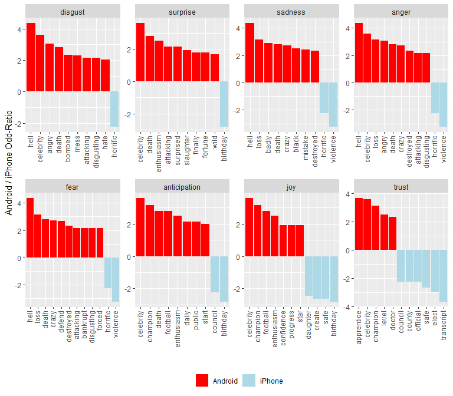

```r
ggplot(tweets_sentiments, aes(word, oddratio, fill = oddratio < 0)) +
  facet_wrap(~ sentiment, scales = "free", nrow = 2) +
  geom_col() +
  theme(axis.text.x = element_text(angle = 90, hjust = 1,vjust = 0.3)) +
  theme(legend.position = 'bottom') +
  labs(x = "", y = "Android / iPhone Odd-Ratio") +
  scale_fill_manual(name = "", labels = c("Android", "iPhone"),
                    values = c("red", "lightblue"))
```

Diese Darstellung bestätigt, dass die Wörter mit negativem Sentiment in den Tweets von *@realDonaldTrump* deutlich häufiger dem Android zuzuordnen sind.

Der Tidying-Ansatz von den Analysen war der Referenz von [David Robinson](http://varianceexplained.org/r/trump-tweets/) entnommen. Das `tidytext` package bietet jedoch mit der Option `token = "tweets"` für die `unnest_tokens`-Funktion einen alternativen *Tidying*-Ansatz, der im Folgenden angewendet wird:

```r
# 'tweets_tidy_sa' steht für 'Tweets tidy für Sentiment Analyse'
tweets_tidy_sa <- tweets %>%
  filter(!str_detect(text, '^"'),
         !str_detect(text, '^RT')) %>%
  unnest_tokens(output = word, input = text, token = "tweets")
```

```
Using `to_lower = TRUE` with `token = 'tweets'` may not preserve URLs.
```

```r
tweets_tidy_sa
```

| id | device | created | word |
| --- | --- | --- | --- |
| 814958820980039681 | Android | 2016-12-30 17:18:18 | russians |
| 814958820980039681 | Android | 2016-12-30 17:18:18 | are |
| 814958820980039681 | Android | 2016-12-30 17:18:18 | playing |
| 814958820980039681 | Android | 2016-12-30 17:18:18 | @cnn |
| 814958820980039681 | Android | 2016-12-30 17:18:18 | and |
| 814958820980039681 | Android | 2016-12-30 17:18:18 | @nbcnews |
| 814958820980039681 | Android | 2016-12-30 17:18:18 | for |
| 814958820980039681 | Android | 2016-12-30 17:18:18 | such |
| 814958820980039681 | Android | 2016-12-30 17:18:18 | fools |
| 814958820980039681 | Android | 2016-12-30 17:18:18 | funny |

[output cut: 990 more lines]

### 3.4.2 *BING*-Lexikon

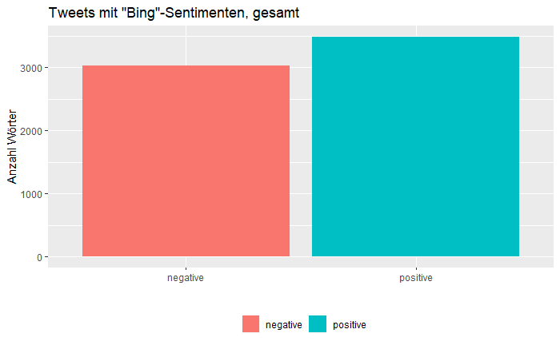

```r
tweets_tidy_sa %>%
  filter(device == "Android") %>%
  inner_join(get_sentiments("bing"), by = "word") %>%
  count(sentiment) %>%
  ggplot(aes(sentiment, n, fill = sentiment)) +
  geom_col() +
  theme(legend.position = 'bottom') +
  labs(title = 'Tweets mit "Bing"-Sentimenten, gesamt',
       x = "",
       y = "Anzahl Wörter",
       fill = "")
```

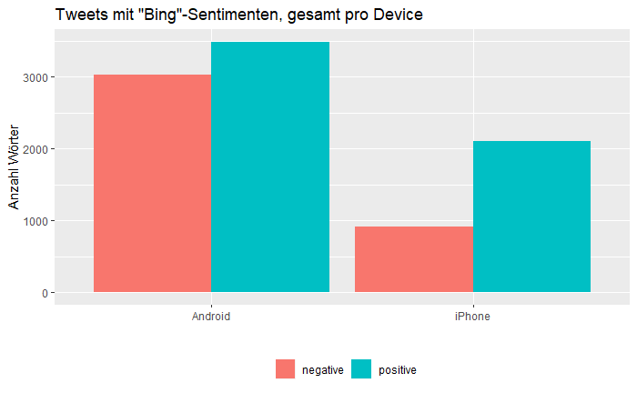

```r
tweets_tidy_sa %>%
  inner_join(get_sentiments("bing"), by = "word") %>%
  count(device, sentiment) %>%
  ggplot(aes(device, n, fill = sentiment)) +
  geom_col(position = position_dodge()) +
  theme(legend.position = 'bottom') +
  labs(title = 'Tweets mit "Bing"-Sentimenten, gesamt pro Device',
       x = "",
       y = "Anzahl Wörter",
       fill = "")
```

Laut *“Bing”*-Sentimenten sind die Tweets vom Android Device und damit diejenigen vom Präsidenten selbst wesentlich negativer als die Tweets vom iPhone. Das bezieht sich auf den gesamten Zeitraum.

### 3.4.3 Sentiment Time Series

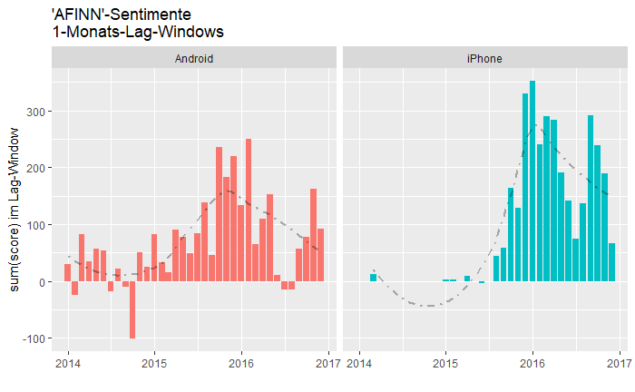

```r
tweets_tidy_sa %>%
  inner_join(get_sentiments("afinn"), by = "word") %>%
  mutate(created = floor_date(created, unit = "1 month")) %>%
  group_by(created, device) %>%
  summarize(score = sum(value)) %>%
  ggplot(aes(created, score, fill = device)) +
  geom_bar(stat = "identity",
           show.legend = FALSE) +
  geom_line(stat = "smooth",
            linetype = 4,
            method = "loess",
            se = F,
            color = "black",
            alpha = 0.3,
            size = 1,
            show.legend = FALSE) +
  facet_wrap(~ device) +
  labs(title = "'AFINN'-Sentimente\n1-Monats-Lag-Windows",
       x = "",
       y = "sum(score) im Lag-Window")
```

Referenz: https://dzone.com/articles/text-analysis-of-trumps-tweets-confirms-he-writes

## 3.5 Topic Modeling

### 3.5.1 Erstellen der Document-Term-Matrix

Zunächst muss aus dem tidy Dataset eine *Document-Term-Matrix* erstellt werden:

```r
tweets_dtm <- tweets_tidy_sa %>%
  filter(!word %in% stop_words$word,
         str_detect(word, "[a-z]")) %>%
  count(id, word) %>%
  cast_dtm(id, word, n)
tweets_dtm
```

```
<<DocumentTermMatrix (documents: 5174, terms: 9154)>>
Non-/sparse entries: 41530/47321266
Sparsity           : 100%
Maximal term length: 34
Weighting          : term frequency (tf)
```

```r
as.matrix(tweets_dtm)[1:4,1:6]
```

```
                    Terms
Docs                 day life rest bullshit expensive freezing
  418365112844824577   1    1    1        0         0        0
  418542137899491328   0    0    0        1         1        1
  419868320180219904   0    0    0        0         0        0
  420333882597466112   0    0    0        0         0        0
```

Wie in den Grundlagen beschrieben, resultiert eine sehr dünn besetzte Matrix.

### 3.5.2 Trainieren des LDA-Modells

Daraufhin kann die **Latent Dirichlet allocation** durchgeführt werden. Die Methode wird zunächst näher spezifiziert, was im Default “quick approximation”, also *Schnelle Schätzung* resultiert.

```r
tweets_lda <- LDA(tweets_dtm, k = 2, control = list(seed = 1234))
tweets_lda
```

```
A LDA_VEM topic model with 2 topics.
```

Die Auftrittswahrscheinlichkeiten $\beta$ pro Wort können dann wie bereits beschrieben mit der `tidy`-Funktion extrahiert werden:

```r
tweets_topics <- tidy(tweets_lda, matrix = "beta")
tweets_topics
```

| topic | term | beta |
| --- | --- | --- |
| 1 | day | 2.420259e-03 |
| 2 | day | 2.315274e-03 |
| 1 | life | 3.019753e-04 |
| 2 | life | 5.980766e-04 |
| 1 | rest | 2.263536e-04 |
| 2 | rest | 2.946310e-04 |
| 1 | bullshit | 2.915584e-05 |
| 2 | bullshit | 6.559147e-05 |
| 1 | expensive | 8.502508e-05 |
| 2 | expensive | 2.940243e-04 |

[output cut: 990 more lines]

Für die Interpretation werden die Ergebnisse weiterverarbeitet. Es werden die Wörter mit den $n$ = 7 höchsten Auftrittswahrscheinlichkeiten $\beta$ ausgewählt.

```r
tweets_topics_top_terms <- tweets_topics %>%
  group_by(topic) %>%
  top_n(7, beta) %>%
  ungroup() %>%
  arrange(topic, -beta)
tweets_topics_top_terms
```

| topic | term | beta |
| --- | --- | --- |
| 1 | trump | 0.009861956 |
| 1 | america | 0.009196626 |
| 1 | time | 0.008318310 |
| 1 | hillary | 0.008248227 |
| 1 | #trump2016 | 0.008138496 |
| 1 | poll | 0.006947007 |
| 1 | #makeamericagreatagain | 0.006633961 |
| 2 | people | 0.011989100 |
| 2 | amp | 0.011974223 |
| 2 | #trump2016 | 0.011517596 |

[output cut: 4 more lines]

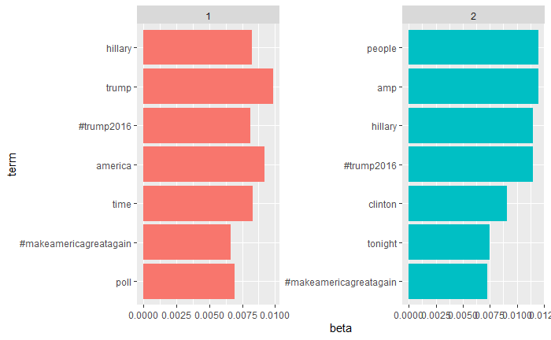

```r
tweets_topics_top_terms %>%
  mutate(term = reorder(term, beta)) %>%
  ggplot(aes(term, beta, fill = as.factor(topic))) +
  geom_col(show.legend = FALSE) +
  facet_wrap(~ topic, scales = "free") +
  coord_flip()
```

Die zwei Themen, die durch *LDA* erfasst wurden, unterscheiden sich zwar, liefern aber keine nennenswerten Erkenntnisse. Das Verfahren wird mit der *“Gibbs”* Methode wiederholt:

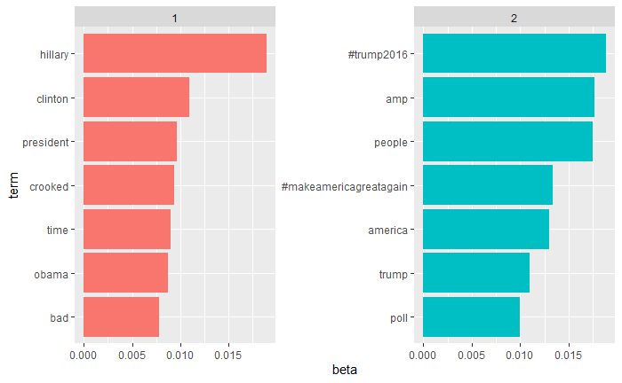

```r
tweets_lda <- LDA(tweets_dtm, k = 2, method = "Gibbs", control = list(seed = 1234))
tweets_topics <- tidy(tweets_lda, matrix = "beta")
tweets_topics_top_terms <- tweets_topics %>%
  group_by(topic) %>%
  top_n(7, beta) %>%
  ungroup() %>%
  arrange(topic, -beta)
tweets_topics_top_terms %>%
  mutate(term = reorder(term, beta)) %>%
  ggplot(aes(term, beta, fill = as.factor(topic))) +
  geom_col(show.legend = FALSE) +
  facet_wrap(~ topic, scales = "free") +
  coord_flip()
```

Nun spiegelt das Ergebnis sinngemäß den Unterschied zwischen den Devices wider. Thema 1 könnte hier nach “Android”, Thema 2 nach “iPhone” benannt werden.

Die Methode wird wiederum wiederholt. Dieses Mal mit $n$ = 6 Themen.

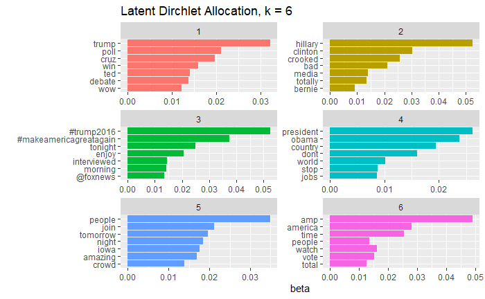

```r
tweets_lda <- LDA(tweets_dtm, k = 6, method = "Gibbs", control = list(seed = 1234))
tweets_topics <- tidy(tweets_lda, matrix = "beta")
tweets_topics_top_terms <- tweets_topics %>%
  group_by(topic) %>%
  top_n(7, beta) %>%
  ungroup() %>%
  arrange(topic, -beta)
tweets_topics_top_terms %>%
  mutate(term = reorder(term, beta)) %>%
  ggplot(aes(term, beta, fill = as.factor(topic))) +
  geom_col(show.legend = FALSE) +
  facet_wrap(~ topic, scales = "free", nrow = 3) +
  coord_flip() +
  labs(title = "Latent Dirchlet Allocation, k = 6",
       x = "")
```

Die Themen sind ausreichend unterschiedlich zueinander und zur Interpretation geeignet. Ihnen nun eine Bedeutung zuzuordnen ist ein subjektiver Prozess. An dieser Stelle wird auch schnell deutlich, dass für das Interpretieren das entsprechende Hintergrundwissen bzw. *Domain-Knowledge* benötigt wird.

Bei Thema sechs fällt jedoch der Bergiff bzw. *Term* “amp” auf.

```r
tweets %>%
  filter(str_detect(text, "amp")) %>%
  .$text %>%
  head()
```

```
[1] "President Obama campaigned hard (and personally) in the very important swing states, and lost.The voters wanted to MAKE AMERICA GREAT AGAIN!"
[2] "I would have done even better in the election, if that is possible, if the winner was based on popular vote - but would campaign differently"
[3] "Campaigning to win the Electoral College is much more difficult &amp; sophisticated than the popular vote. Hillary focused on the wrong states!"
[4] "If my many supporters acted and threatened people like those who lost the election are doing, they would be scorned &amp; called terrible names!"
[5] "RT @DanScavino: Join #PEOTUS Trump &amp; #VPEOTUS Pence live in West Allis, Wisconsin! \n#ThankYouTour2016 #MAGA\nhttps://t.co/vU5EPIYKUc https:/…"
[6] "Whether I choose him or not for \"State\"- Rex Tillerson, the Chairman &amp; CEO of ExxonMobil, is a world class player and dealmaker. Stay tuned!"
```

# 4 Zusammenfassung der Ergebnisse

Die zuvor schon von anderen Usern der Data Science Community (und vor allem durch Todd Vaziri) aufgestellte Hypothese, US Präsident Donald Trump sei nicht alleiniger Autor des Twitter Accounts *@realDonaldTrump* konnte bestätigt werden. Die Tweets des Präsidenten können im Zeitraum vom Februar 2013 bis März 2017 anhand des Devices in Cluster eingeteilt werden. Diese Erkenntnis ist nicht neu, jedoch für die Glaubwürdigkeit der nachfolgenden Ergebnisse wichtig, denn sie werden somit untermauert.

Für das Topic Modeling war eines der Ziele, eine geeignete Methode zu finden, die Themen in der Praxis errechnen automatisiert kann. Mit LDA wurde ein Ansatz aus dem Bereich des Maschinellen Lernens herausgesucht und angewendet. Die Ergebnisse können als sinngebend betrachtet werden. Es können den einzelnen Clustern tatsächlich Themenüberschriften, bzw. Beschreibungen zugeordnet werden, sie sind jedoch relativ subjektiv formuliert und zugeordnet. Das dafür benötigte Domänenwissen ist höher als bei der Sentimentanalyse einzustufen. Für die Analyse wurde zunächst Topic Modeling mit $k=2$ und anschließen $k=6$ durchgeführt. Für weitere Analysen sind andere Einstellungen für den Tuning-Parameter $k$ denkbar.

**Ausblick:** Die Analysen können also noch weiterverfolgt werden. In Hinsicht auf die hohe Anzahl der Tweets und dem relativ hohen Zeitraum, ist es durchaus möglich, dass eine wesentlich höherer Parameter für $k$ noch sinnvolle Ergebnisse liefern kann.

# 5 Appendix

Alternative Einstellung der Topic Modelling untersuchung.

[figure not shown]

```r
tweets_dtm <- tweets_tidy_sa %>%
  filter(!word %in% c(stop_words$word,"amp"),
         str_detect(word, "[a-z]")) %>%
  count(id, word) %>%
  cast_dtm(id, word, n)
tweets_lda <- LDA(tweets_dtm, k = 20, method = "Gibbs", control = list(seed = 1234))
tweets_topics <- tidy(tweets_lda, matrix = "beta")
tweets_topics_top_terms <- tweets_topics %>%
  group_by(topic) %>%
  top_n(7, beta) %>%
  ungroup() %>%
  arrange(topic, -beta)
tweets_topics_top_terms %>%
  mutate(term = reorder(term, beta)) %>%
  ggplot(aes(term, beta, fill = as.factor(topic))) +
  geom_col(show.legend = FALSE) +
  facet_wrap(~ topic, scales = "free", ncol = 2) +
  coord_flip()
```